# Lab 3: ggplot2 and Visualization Principles

In May 2020, the [Georgia Department of Public Health](https://dph.georgia.gov/covid-19-daily-status-report) posted the following plot to illustrate the number of confirmed COVID-19 cases in their hardest-hit counties over a two-week period.

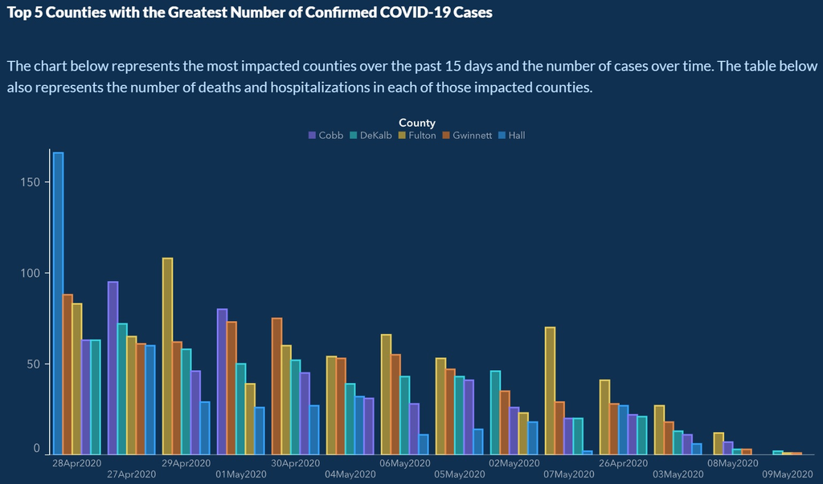

The plot was heavily criticized by the statistical community and several media outlets for its deceptive portrayal of COVID-19 trends in Georgia. Whether the end result was due to malicious intent or simply poor judgment, it is incredibly irresponsible to publish data visualizations that obscure and distort the truth.

In this lab, we will pretend that we are data scientists tasked with the job of making better COVID-19 visualizations. This will also give us an opportunity to practice making more aesthetically pleasing plots using the `ggplot2` package. For the remainder of the course, you will be expected to use `ggplot2` any time you create a plot.

```r
library(readr)
library(dplyr)
library(ggplot2)
library(gridExtra)

# Replace "us-counties.csv" with
# "https://raw.githubusercontent.com/nytimes/covid-19-data/master/us-counties.csv"
# to pull most up-to-date version from Github
us_counties = read_csv("https://raw.githubusercontent.com/nytimes/covid-19-data/master/us-counties.csv")
```

This lab (particularly questions 10 and 11) borrows ideas and code from Peter Ellis’s [blog post](http://freerangestats.info/blog/2020/05/23/ordering-in-bar-charts).

1. Create a new data frame called `georgia_counties` that only contains the data from Georgia. Add a new variable called `new_cases` that stores the number of new confirmed cases for each day at the county level. Hint: the `lag` function returns the previous values in a vector.

You can extract the number of new cases from the case totals using the lag function. In this toy example, cases records the daily total/cumulative number of cases over a two-week period. By default, the lag function simply shifts the vector of cases back by one. The number of new cases on each day is then the difference between cases and lag(cases).

Useful for comparing values behind of or ahead of the current values.

```r
#lag function returns the previous values in a vector -- See attached Lag.pdf
#number of cases:
cases = c(13, 15, 18, 22, 29, 39, 59, 61, 62, 67, 74, 89, 108, 122)
cases
```

```
##  [1]  13  15  18  22  29  39  59  61  62  67  74  89 108 122
```

```r
lag(cases)
```

```
##  [1]  NA  13  15  18  22  29  39  59  61  62  67  74  89 108
```

```r
new_cases = cases - lag(cases)
new_cases
```

```
##  [1] NA  2  3  4  7 10 20  2  1  5  7 15 19 14
```

```r
head(us_counties)
```

```
## # A tibble: 6 × 6
##   date       county    state      fips  cases deaths
##   <date>     <chr>     <chr>      <chr> <dbl>  <dbl>
## 1 2020-01-21 Snohomish Washington 53061     1      0
## 2 2020-01-22 Snohomish Washington 53061     1      0
## 3 2020-01-23 Snohomish Washington 53061     1      0
## 4 2020-01-24 Cook      Illinois   17031     1      0
## 5 2020-01-24 Snohomish Washington 53061     1      0
## 6 2020-01-25 Orange    California 06059     1      0
```

```r
#Hint: you want to calculate new cases within each county of Georgia state and use the lag() function

#1) Dataset with Georgia counties
#2) group by counties
#3) make new cases variable

georgia_counties<- us_counties %>% filter(state == "Georgia") %>%
  group_by(county) %>%
  arrange(date) %>%
  mutate(new_cases = cases - lag(cases)) %>%
  ungroup()

head(georgia_counties)
```

```
## # A tibble: 6 × 7
##   date       county state   fips  cases deaths new_cases
##   <date>     <chr>  <chr>   <chr> <dbl>  <dbl>     <dbl>
## 1 2020-03-02 Fulton Georgia 13121     2      0        NA
## 2 2020-03-03 Fulton Georgia 13121     2      0         0
## 3 2020-03-04 Fulton Georgia 13121     2      0         0
## 4 2020-03-05 Fulton Georgia 13121     2      0         0
## 5 2020-03-06 Fulton Georgia 13121     2      0         0
## 6 2020-03-06 Polk   Georgia 13233     1      0        NA
```

2. Today is May 9th, 2020. You want to get a sense of today’s distribution of the total number of confirmed cases in each county in Georgia.

Make three histograms, one with 10 black bins, one with 30 red bins, and one with 50 blue bins. Include nice axis labels and titles. Use the `grid.arrange` function from the `gridExtra` package to place the three plots next to each other.

```r
#Hint: can use as.Date("2020-05-09") to find desired values
str(georgia_counties)
```

```
## tibble [124,889 × 7] (S3: tbl_df/tbl/data.frame)
##  $ date     : Date[1:124889], format: "2020-03-02" "2020-03-03" ...
##  $ county   : chr [1:124889] "Fulton" "Fulton" "Fulton" "Fulton" ...
##  $ state    : chr [1:124889] "Georgia" "Georgia" "Georgia" "Georgia" ...
##  $ fips     : chr [1:124889] "13121" "13121" "13121" "13121" ...
##  $ cases    : num [1:124889] 2 2 2 2 2 1 1 4 1 1 ...
##  $ deaths   : num [1:124889] 0 0 0 0 0 0 0 0 0 0 ...
##  $ new_cases: num [1:124889] NA 0 0 0 0 NA NA 2 NA 0 ...
```

```r
#New dataframe with 5/9/20 data

georgia_counties_may9<- georgia_counties %>% filter(date == as.Date("2020-05-09"))
head(georgia_counties_may9,10)
```

```
## # A tibble: 10 × 7
##    date       county   state   fips  cases deaths new_cases
##    <date>     <chr>    <chr>   <chr> <dbl>  <dbl>     <dbl>
##  1 2020-05-09 Appling  Georgia 13001    92     10         3
##  2 2020-05-09 Atkinson Georgia 13003    20      1         0
##  3 2020-05-09 Bacon    Georgia 13005    41      1         6
##  4 2020-05-09 Baker    Georgia 13007    31      2         0
##  5 2020-05-09 Baldwin  Georgia 13009   270     12        -1
##  6 2020-05-09 Banks    Georgia 13011    36      0         1
##  7 2020-05-09 Barrow   Georgia 13013   194      5         2
##  8 2020-05-09 Bartow   Georgia 13015   361     31         0
##  9 2020-05-09 Ben Hill Georgia 13017    39      0         0
## 10 2020-05-09 Berrien  Georgia 13019    19      0         0
```

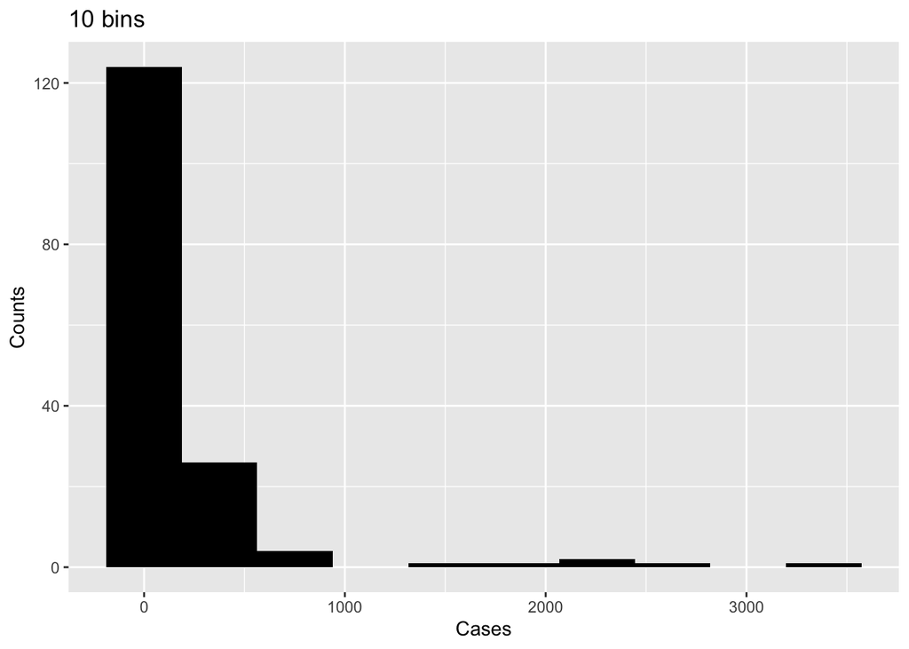

```r
#Histogram 1- 10 black bins
hist1<-georgia_counties_may9 %>% ggplot(aes(x=cases)) +
  geom_histogram(bins = 10, fill = "black") +
  ggtitle("10 bins") + xlab("Cases") + ylab("Counts")

hist1
```

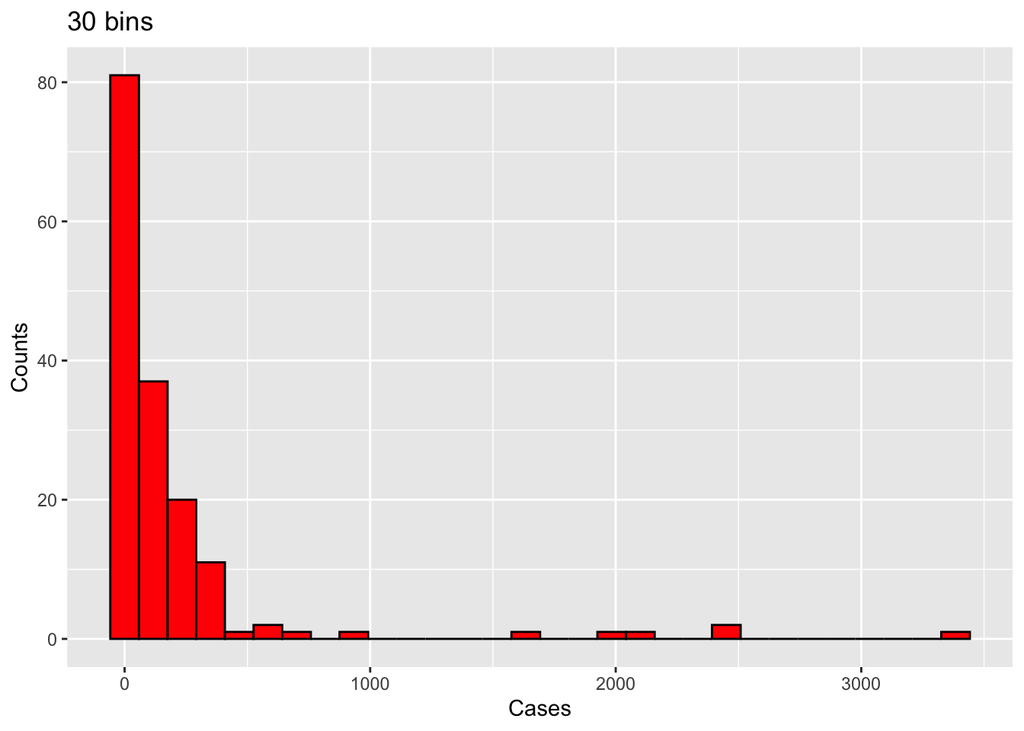

```r
##--- Another way to add labels--
# georgia_counties_may9 %>% ggplot(aes(x=cases)) +
# geom_histogram(bins = 10, fill = "black") +
# labs(title = "10 bins", x = 'Cases',
#        y = 'Count')

#Histogram 2- 30 red bins - default

hist2<-georgia_counties_may9 %>% ggplot(aes(x=cases)) +
  geom_histogram(bins = 30, color = "black", fill = "red") +
  ggtitle("30 bins") + xlab("Cases") + ylab("Counts")

hist2
```

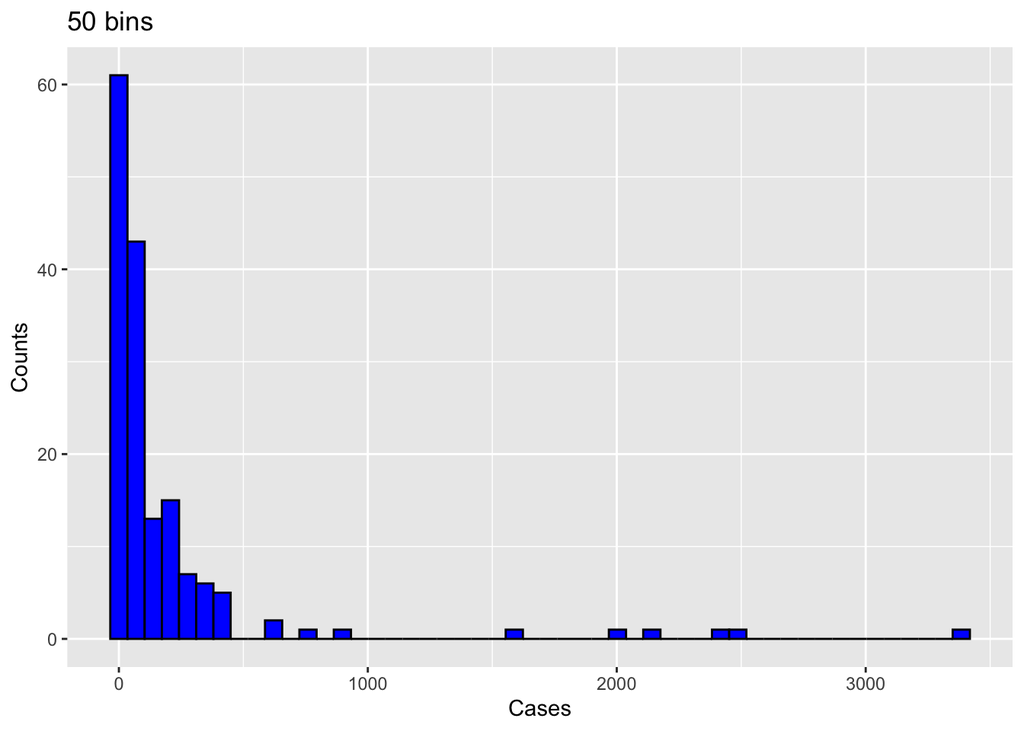

```r
##Histogram 3- 50 blue bins
hist3<-georgia_counties_may9 %>% ggplot(aes(x=cases)) +
  geom_histogram(bins = 50, color = "black", fill = "blue") +
  ggtitle("50 bins") + xlab("Cases") + ylab("Counts")

hist3
```

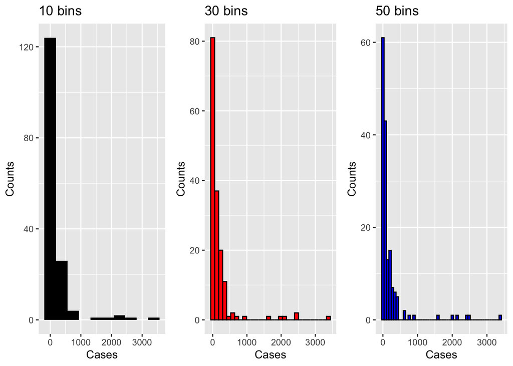

```r
# Save histograms side-by-side
grid.arrange(hist1, hist2, hist3, ncol = 3)
```

3. A single day doesn’t tell the whole story, so you decide to look at the data from the past two weeks, April 26 to May 9, 2020.

Boxplots can be easier to interpret than histograms when you are comparing the distributions of multiple groups. Draw boxplots of the total number of confirmed cases in each county by date. Try this with and without a log (base 10) transformation.

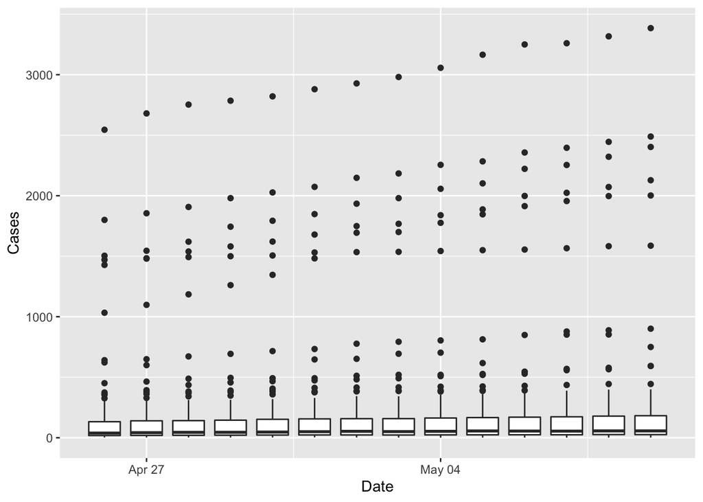

```r
#Hint: Make a data frame that stores only the data from April 26 to May 9, 2020.

#Subset dataframe
georgia_counties_apr26_may9<-georgia_counties %>%
  filter(date <= as.Date("2020-05-09") & date >= as.Date("2020-04-26"))

#Boxplots
georgia_counties_apr26_may9 %>% ggplot(aes(x= date, y = cases, group=date)) +
  geom_boxplot() + xlab("Date") + ylab("Cases")
```

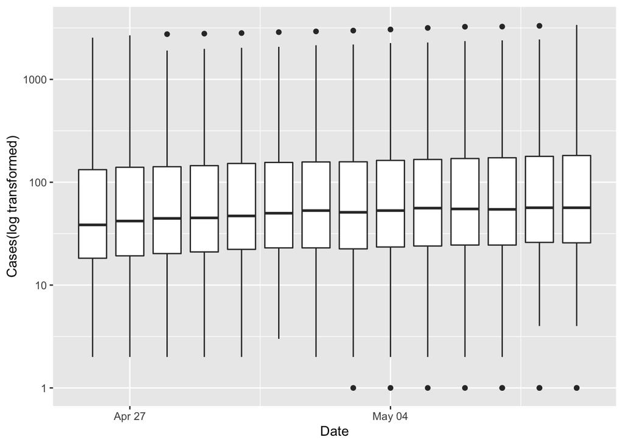

```r
#function to change breaks: scale_x_continuous(), scale_y_continuous()

#Log-transformations

#changes the scale to increase -- R uses natural log
georgia_counties_apr26_may9 %>% ggplot(aes(x= date, y = cases, group=date)) +
  geom_boxplot() + xlab("Date") + ylab("Cases(log transformed)") +
  scale_y_log10()
```

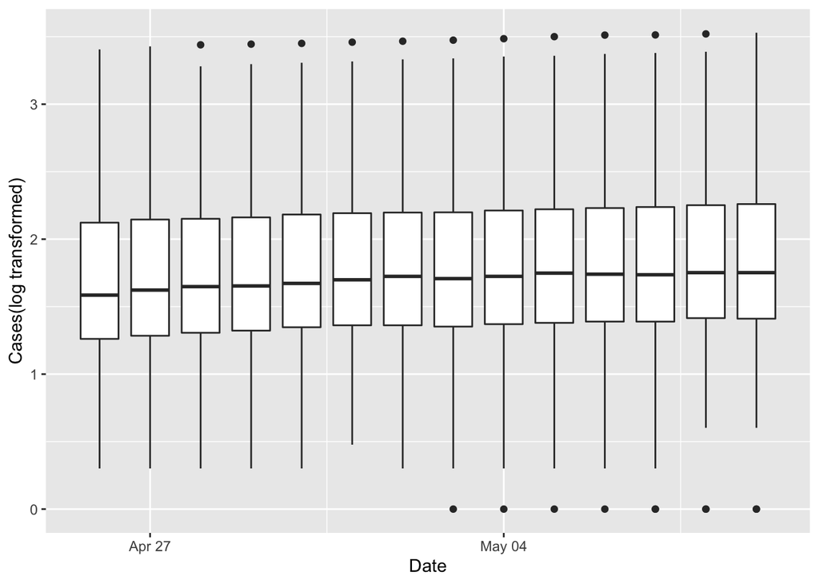

```r
#Transforms the data
georgia_counties_apr26_may9 %>% ggplot(aes(x= date, y = log10(cases), group=date)) +
  geom_boxplot() + xlab("Date") + ylab("Cases(log transformed)")
```

4. From your plots in Questions 2 and 3, it is clear that there are some counties with a lot of cases! It might be useful to study them more closely. Identify the five most impacted counties, which we will take to be the counties with the highest case totals on May 9, 2020.
5. We are not going to spend time bending over backwards to try to re-create the very bad barplot from the Georgia DPH, but Peter Ellis explains how to do it in his [blog post](http://freerangestats.info/blog/2020/05/23/ordering-in-bar-charts). Instead, make an improved clustered barplot of the new cases reported in the 5 most impacted counties between April 26 and May 9. Be sure to order the dates chronologically on the x-axis and maintain the order of the counties within each day’s cluster of bars. Does your impression of the COVID-19 situation in Georgia change?

```r
#Hint: Use the result from Q4 and subset your dataframe by the 5 most impacted counties
```

6. While much improved, the clustered barplot still makes it difficult to compare trends over time in the five counties. Present the data as a line plot with the date on the x-axis, the number of new cases on the y-axis, and each county plotted as a separate line.
7. Several months have passed and it is now September 30, 2020 (or whatever the most recent date is in your data). Update your plot from Question 6 so that it includes all of the data from the start of the pandemic until today.
8. Unfortunately, because you have so much more data now, it is difficult to see the separate lines in your plot from Question 7 and draw conclusions. Try plotting all of the lines in gray and adding a black line representing the average number of new cases across the five counties.
9. The line plot from Question 8 is a lot easier on the eyes, but it doesn’t resolve the issue that we are unable to visually compare the five counties. Try making a scatterplot of the data, with slightly transparent points colored by county. Then, add a loess line for each county that smooths over local points (advanced). This will help you track the general trends in each county, instead of being distracted by all of the day-to-day variability.
10. Instead of putting all of the points and loess lines in a single plot, make a multi-panel plot with a panel for each country using `facet_wrap`.
11. (Optional, advanced) Re-create your plot from Question 5 so that the colors and text match the very bad barplot published by the Georgia DPH.